# Week 5 Case Study: Autoencoders & Generative Models

**Student Name:** Siddhartha Mukherjee

**Course:** Applied Research Topics in Deep Learning

**Date:** 2026-05-04

### Part 0: Environment Setup

Import libraries, set random seeds, and verify GPU availability.

```python
!pip install tensorflow tensorflow-datasets nltk matplotlib seaborn scikit-learn -q
```

```python
# ---- Part 0: Environment Setup ----
import os, random, time, math
import numpy as np
import pandas as pd
import matplotlib.pyplot as plt
import seaborn as sns
import tensorflow as tf
from tensorflow import keras
from tensorflow.keras import layers
from sklearn.decomposition import PCA
from sklearn.manifold import TSNE

SEED = 42
os.environ['PYTHONHASHSEED'] = str(SEED)
random.seed(SEED)
np.random.seed(SEED)
tf.random.set_seed(SEED)

print('TensorFlow version:', tf.__version__)
gpus = tf.config.list_physical_devices('GPU')
print('GPU available:', len(gpus) > 0)
if gpus:
    for g in gpus:
        print('  ->', g.name)

sns.set_style('whitegrid')
plt.rcParams['figure.dpi'] = 100
```

```
TensorFlow version: 2.20.0
GPU available: True
  -> /physical_device:GPU:0
```

## Approach Note

We use the **MNIST handwritten digits dataset** as specified in the assignment. MNIST contains 28×28 grayscale images of digits 0–9, with 60,000 training and 10,000 test samples. Images are normalised to `[-1, 1]` for the VAE and GAN (which use `tanh` output activation) and to `[0, 1]` for the basic autoencoder (which uses `sigmoid` output activation).

### Part 1.1: Load MNIST and inspect dataset shape, label distribution, and pixel range.

```python
# ---- Part 1.1: Load MNIST ----
(x_train_raw, y_train), (x_test_raw, y_test) = keras.datasets.mnist.load_data()

print("Train images shape:", x_train_raw.shape)
print("Test images shape :", x_test_raw.shape)
print("Train labels shape:", y_train.shape)
print("Pixel value range :", x_train_raw.min(), "to", x_train_raw.max())
print("Data type         :", x_train_raw.dtype)

unique, counts = np.unique(y_train, return_counts=True)
print("\nClass distribution in training set:")
for u, c in zip(unique, counts):
    print(f"  Digit {u}: {c} samples")
```

```
Train images shape: (60000, 28, 28)
Test images shape : (10000, 28, 28)
Train labels shape: (60000,)
Pixel value range : 0 to 255
Data type         : uint8

Class distribution in training set:
  Digit 0: 5923 samples
  Digit 1: 6742 samples
  Digit 2: 5958 samples
  Digit 3: 6131 samples
  Digit 4: 5842 samples
  Digit 5: 5421 samples
  Digit 6: 5918 samples
  Digit 7: 6265 samples
  Digit 8: 5851 samples
  Digit 9: 5949 samples
```

### Part 1.2: Apply normalisation in two ranges and create a train/validation split.

```python
# ---- Part 1.2: Normalisation and Train/Val split ----
x_train_raw = x_train_raw[..., np.newaxis].astype("float32")
x_test_raw  = x_test_raw[..., np.newaxis].astype("float32")

# Version 1: [0, 1] range — used for autoencoder (sigmoid output)
x_train_01 = x_train_raw / 255.0
x_test_01  = x_test_raw / 255.0

# Version 2: [-1, 1] range — used for VAE/GAN (tanh output)
x_train_11 = (x_train_raw / 127.5) - 1.0
x_test_11  = (x_test_raw / 127.5) - 1.0

# Train/Validation split (54k/6k)
val_size = 6000
x_val_01,   x_train_01 = x_train_01[:val_size],  x_train_01[val_size:]
x_val_11,   x_train_11 = x_train_11[:val_size],  x_train_11[val_size:]
y_val,      y_train_s  = y_train[:val_size],     y_train[val_size:]

print("Train [0,1]   :", x_train_01.shape, "range:", x_train_01.min(), x_train_01.max())
print("Val   [0,1]   :", x_val_01.shape)
print("Train [-1,1]  :", x_train_11.shape, "range:", x_train_11.min(), x_train_11.max())
print("Test  [0,1]   :", x_test_01.shape)
```

```
Train [0,1]   : (54000, 28, 28, 1) range: 0.0 1.0
Val   [0,1]   : (6000, 28, 28, 1)
Train [-1,1]  : (54000, 28, 28, 1) range: -1.0 1.0
Test  [0,1]   : (10000, 28, 28, 1)
```

### Part 1.3: Visualise sample images and analyse pixel value distributions.

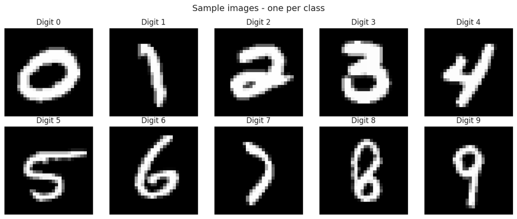

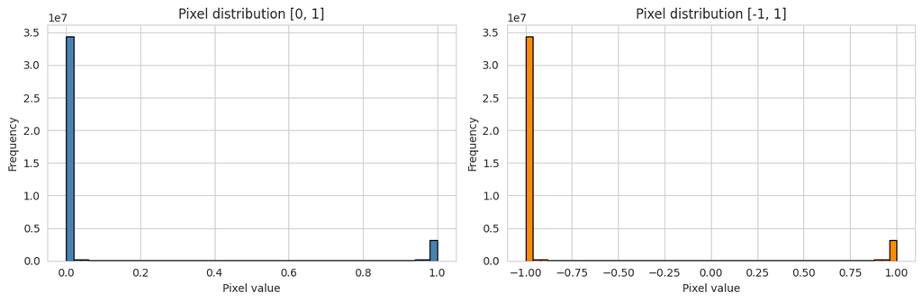

```
Mean pixel value (train [0,1]): 0.1306
Std  pixel value (train [0,1]): 0.308
Mean pixel value (train [-1,1]): -0.7389
```

```python
# ---- Part 1.3: Sample grid and pixel histogram ----
fig, axes = plt.subplots(2, 5, figsize=(12, 5))
axes = axes.flatten()
for i in range(10):
    idx = np.where(y_train_s == i)[0][0]
    axes[i].imshow(x_train_01[idx].squeeze(), cmap='gray')
    axes[i].set_title(f"Digit {i}")
    axes[i].axis('off')
plt.suptitle("Sample images - one per class", fontsize=14)
plt.tight_layout()
plt.show()

plt.figure(figsize=(12, 4))
plt.subplot(1, 2, 1)
plt.hist(x_train_01.flatten(), bins=50, color='steelblue', edgecolor='black')
plt.title("Pixel distribution [0, 1]")
plt.xlabel("Pixel value"); plt.ylabel("Frequency")

plt.subplot(1, 2, 2)
plt.hist(x_train_11.flatten(), bins=50, color='darkorange', edgecolor='black')
plt.title("Pixel distribution [-1, 1]")
plt.xlabel("Pixel value"); plt.ylabel("Frequency")
plt.tight_layout(); plt.show()

print("Mean pixel value (train [0,1]):", x_train_01.mean().round(4))
print("Std  pixel value (train [0,1]):", x_train_01.std().round(4))
print("Mean pixel value (train [-1,1]):", x_train_11.mean().round(4))
```

### Part 1.4: Define mild augmentation suitable for digit data and build tf.data pipelines.

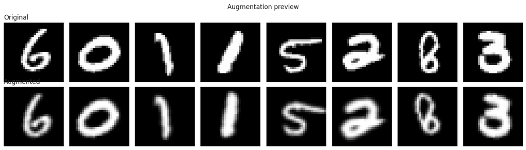

```
Pipelines ready.
AE train batches : 422
VAE train batches: 422
```

```python
# ---- Part 1.4: Augmentation and tf.data pipelines ----
# Note: Horizontal flip is not used for digits because flipping changes meaning
# (for example, the digit 6 becomes similar to a mirrored shape, and 2/5 are sensitive).
# Only mild rotation, zoom and translation are applied.

data_augmentation = keras.Sequential([
    layers.RandomRotation(0.05),
    layers.RandomZoom(0.05),
    layers.RandomTranslation(0.05, 0.05)
], name='data_augmentation')

sample = x_train_01[:8]
augmented = data_augmentation(sample, training=True)

fig, axes = plt.subplots(2, 8, figsize=(14, 4))
for i in range(8):
    axes[0, i].imshow(sample[i].squeeze(), cmap='gray');     axes[0, i].axis('off')
    axes[1, i].imshow(augmented[i].numpy().squeeze(), cmap='gray'); axes[1, i].axis('off')
axes[0, 0].set_title("Original", loc='left')
axes[1, 0].set_title("Augmented", loc='left')
plt.suptitle("Augmentation preview")
plt.tight_layout(); plt.show()

BATCH = 128

def make_ds(x, batch=BATCH, shuffle=True, augment=False):
    ds = tf.data.Dataset.from_tensor_slices(x)
    if shuffle:
        ds = ds.shuffle(buffer_size=2048, seed=SEED)
    ds = ds.batch(batch)
    if augment:
        ds = ds.map(lambda b: data_augmentation(b, training=True),
                    num_parallel_calls=tf.data.AUTOTUNE)
    return ds.prefetch(tf.data.AUTOTUNE)

ds_train_ae  = make_ds(x_train_01, augment=False)
ds_val_ae    = make_ds(x_val_01,   shuffle=False)
ds_train_vae = make_ds(x_train_11, augment=False)
ds_val_vae   = make_ds(x_val_11,   shuffle=False)
ds_train_gan = make_ds(x_train_11, augment=False)

print("Pipelines ready.")
print("AE train batches :", tf.data.experimental.cardinality(ds_train_ae).numpy())
print("VAE train batches:", tf.data.experimental.cardinality(ds_train_vae).numpy())
```

### Part 1.5: Apply the augmentation pipeline to a separate training stream and confirm output range and shape are preserved.

```
Augmented AE pipeline cardinality: 422 batches
Batch shape : (128, 28, 28, 1)
Value range : 0.0 to 1.0
```

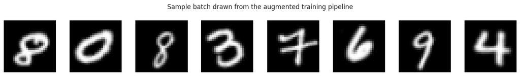

[output not shown]

```python
# ---- Part 1.5: Demonstrate augmented pipeline in actual use ----
# Augmentation is most useful for the basic AE to improve generalisation.
# For VAE/GAN we keep the unaugmented stream so that the learned distribution
# matches the true MNIST distribution exactly.

ds_train_ae_aug = make_ds(x_train_01, augment=True)
print("Augmented AE pipeline cardinality:",
      tf.data.experimental.cardinality(ds_train_ae_aug).numpy(), "batches")

# Verify a batch
for sample_batch in ds_train_ae_aug.take(1):
    print("Batch shape :", sample_batch.shape)
    print("Value range :", float(tf.reduce_min(sample_batch)),
          "to", float(tf.reduce_max(sample_batch)))

# Visualise an augmented batch from the actual pipeline
fig, axes = plt.subplots(1, 8, figsize=(14, 2))
for i in range(8):
    axes[i].imshow(sample_batch[i].numpy().squeeze(), cmap='gray')
    axes[i].axis('off')
plt.suptitle("Sample batch drawn from the augmented training pipeline")
plt.tight_layout(); plt.show()

print("\nDesign choice: augmentation is enabled for the AE stream "
      "(better generalisation) and disabled for VAE/GAN streams "
      "(to preserve the true data distribution for generative modelling).")
```

### Part 1 Summary

The MNIST dataset (60,000 training and 10,000 test samples, 28×28×1) was loaded and split into 54,000 training and 6,000 validation samples. Two normalised versions were retained: `[0, 1]` for the autoencoder and `[-1, 1]` for the VAE and GAN. Augmentation is restricted to small rotations, zooms and translations, since horizontal flips would alter the semantic identity of digits. Pixel histograms confirm that MNIST has a bimodal distribution dominated by dark background pixels and bright stroke pixels.

### Part 2.1: Build and train a basic dense autoencoder as a baseline.

```python
# ---- Part 2.1: Basic Dense Autoencoder ----
def build_basic_ae(latent_dim=64):
    inputs = keras.Input(shape=(28, 28, 1))
    x = layers.Flatten()(inputs)
    x = layers.Dense(256, activation='relu')(x)
    x = layers.Dense(128, activation='relu')(x)
    z = layers.Dense(latent_dim, activation='relu', name='z')(x)

    x = layers.Dense(128, activation='relu')(z)
    x = layers.Dense(256, activation='relu')(x)
    x = layers.Dense(28*28, activation='sigmoid')(x)
    outputs = layers.Reshape((28, 28, 1))(x)

    encoder = keras.Model(inputs, z, name='basic_encoder')
    autoencoder = keras.Model(inputs, outputs, name='basic_autoencoder')
    return encoder, autoencoder

enc_basic, ae_basic = build_basic_ae(latent_dim=64)
ae_basic.compile(optimizer=keras.optimizers.Adam(1e-3), loss='mse')
ae_basic.summary()

hist_basic = ae_basic.fit(x_train_01, x_train_01,
                          validation_data=(x_val_01, x_val_01),
                          epochs=8, batch_size=128, verbose=1)
```

```
Model: "basic_autoencoder"
```

```
┏━━━━━━━━━━━━━━━━━━━━━━━━━━━━━━━━━┳━━━━━━━━━━━━━━━━━━━━━━━━┳━━━━━━━━━━━━━━━┓
┃ Layer (type)                    ┃ Output Shape           ┃       Param # ┃
┡━━━━━━━━━━━━━━━━━━━━━━━━━━━━━━━━━╇━━━━━━━━━━━━━━━━━━━━━━━━╇━━━━━━━━━━━━━━━┩
│ input_layer_1 (InputLayer)      │ (None, 28, 28, 1)      │             0 │
├─────────────────────────────────┼────────────────────────┼───────────────┤
│ flatten (Flatten)               │ (None, 784)            │             0 │
├─────────────────────────────────┼────────────────────────┼───────────────┤
│ dense (Dense)                   │ (None, 256)            │       200,960 │
├─────────────────────────────────┼────────────────────────┼───────────────┤
│ dense_1 (Dense)                 │ (None, 128)            │        32,896 │
├─────────────────────────────────┼────────────────────────┼───────────────┤
│ z (Dense)                       │ (None, 64)             │         8,256 │
├─────────────────────────────────┼────────────────────────┼───────────────┤
│ dense_2 (Dense)                 │ (None, 128)            │         8,320 │
├─────────────────────────────────┼────────────────────────┼───────────────┤
│ dense_3 (Dense)                 │ (None, 256)            │        33,024 │
├─────────────────────────────────┼────────────────────────┼───────────────┤
│ dense_4 (Dense)                 │ (None, 784)            │       201,488 │
├─────────────────────────────────┼────────────────────────┼───────────────┤
│ reshape (Reshape)               │ (None, 28, 28, 1)      │             0 │
└─────────────────────────────────┴────────────────────────┴───────────────┘
```

```
 Total params: 484,944 (1.85 MB)
```

```
 Trainable params: 484,944 (1.85 MB)
```

```
 Non-trainable params: 0 (0.00 B)
```

```
422/422 ━━━━━━━━━━━━━━━━━━━━ 29s 37ms/step - loss: 0.0416 - val_loss: 0.0200
422/422 ━━━━━━━━━━━━━━━━━━━━ 1s 2ms/step - loss: 0.0169 - val_loss: 0.0140
422/422 ━━━━━━━━━━━━━━━━━━━━ 1s 2ms/step - loss: 0.0129 - val_loss: 0.0115
422/422 ━━━━━━━━━━━━━━━━━━━━ 1s 2ms/step - loss: 0.0110 - val_loss: 0.0102
422/422 ━━━━━━━━━━━━━━━━━━━━ 1s 2ms/step - loss: 0.0098 - val_loss: 0.0092
422/422 ━━━━━━━━━━━━━━━━━━━━ 1s 2ms/step - loss: 0.0090 - val_loss: 0.0084
422/422 ━━━━━━━━━━━━━━━━━━━━ 1s 2ms/step - loss: 0.0083 - val_loss: 0.0078
422/422 ━━━━━━━━━━━━━━━━━━━━ 1s 2ms/step - loss: 0.0077 - val_loss: 0.0074
```

### Part 2.2: Build a convolutional autoencoder and compare four latent dimensions (32, 64, 128, 256).

```python
# ---- Part 2.2: Convolutional Autoencoder with latent-dimension sweep ----
def build_conv_ae(latent_dim=64):
    inputs = keras.Input(shape=(28, 28, 1))
    x = layers.Conv2D(32, 3, strides=2, padding='same', activation='relu')(inputs)
    x = layers.Conv2D(64, 3, strides=2, padding='same', activation='relu')(x)
    x = layers.Flatten()(x)
    z = layers.Dense(latent_dim, activation='relu', name='z')(x)

    d = layers.Dense(7*7*64, activation='relu')(z)
    d = layers.Reshape((7, 7, 64))(d)
    d = layers.Conv2DTranspose(64, 3, strides=2, padding='same', activation='relu')(d)
    d = layers.Conv2DTranspose(32, 3, strides=2, padding='same', activation='relu')(d)
    outputs = layers.Conv2D(1, 3, padding='same', activation='sigmoid')(d)

    encoder = keras.Model(inputs, z, name=f'conv_encoder_d{latent_dim}')
    autoencoder = keras.Model(inputs, outputs, name=f'conv_ae_d{latent_dim}')
    return encoder, autoencoder

latent_dims = [32, 64, 128, 256]
results = {}
encoders = {}
autoencoders = {}

for ld in latent_dims:
    print(f"\n=== Training Conv AE with latent_dim = {ld} ===")
    enc, ae = build_conv_ae(latent_dim=ld)
    ae.compile(optimizer=keras.optimizers.Adam(1e-3), loss='mse')
    hist = ae.fit(x_train_01, x_train_01,
                  validation_data=(x_val_01, x_val_01),
                  epochs=6, batch_size=128, verbose=0)

    recon = ae.predict(x_test_01[:1000], verbose=0)
    mse  = float(tf.reduce_mean((x_test_01[:1000] - recon)**2))
    ssim = float(tf.reduce_mean(tf.image.ssim(x_test_01[:1000], recon, max_val=1.0)))
    results[ld] = {'mse': mse, 'ssim': ssim, 'val_loss': hist.history['val_loss'][-1]}
    encoders[ld] = enc
    autoencoders[ld] = ae
    print(f"  -> Test MSE: {mse:.5f} | Test SSIM: {ssim:.4f}")

print("\n" + "="*55)
print(f"{'Latent dim':<12}{'Test MSE':<15}{'Test SSIM':<15}{'Val loss':<12}")
print("="*55)
for ld in latent_dims:
    r = results[ld]
    print(f"{ld:<12}{r['mse']:<15.5f}{r['ssim']:<15.4f}{r['val_loss']:<12.5f}")
```

```
=== Training Conv AE with latent_dim = 32 ===
  -> Test MSE: 0.00542 | Test SSIM: 0.9383

=== Training Conv AE with latent_dim = 64 ===
  -> Test MSE: 0.00298 | Test SSIM: 0.9674

=== Training Conv AE with latent_dim = 128 ===
  -> Test MSE: 0.00250 | Test SSIM: 0.9726

=== Training Conv AE with latent_dim = 256 ===
  -> Test MSE: 0.00201 | Test SSIM: 0.9781

=======================================================
Latent dim  Test MSE       Test SSIM      Val loss
=======================================================
32          0.00542        0.9383         0.00552
64          0.00298        0.9674         0.00306
128         0.00250        0.9726         0.00255
256         0.00201        0.9781         0.00205
```

### Part 2.3: Visualise reconstructions across latent dimensions and project the latent space using PCA.

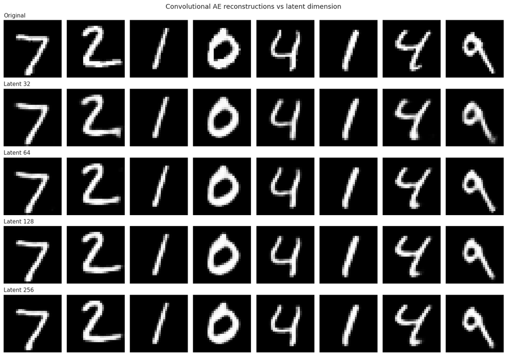

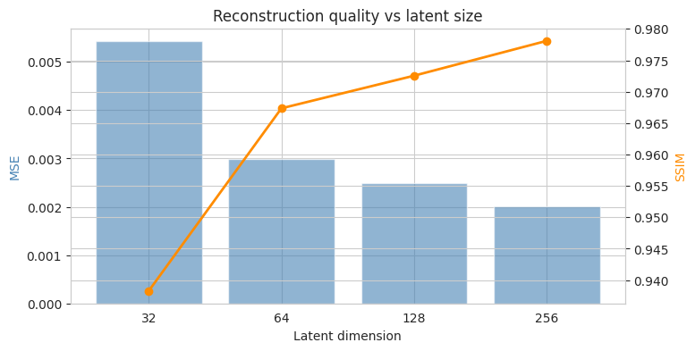

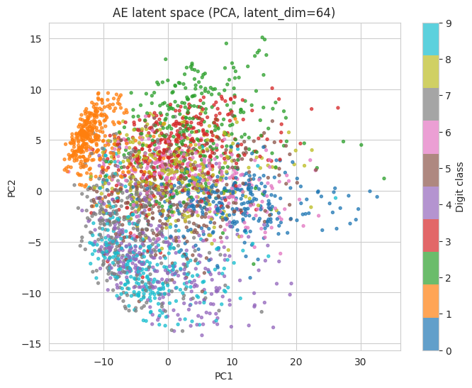

```python
# ---- Part 2.3: Reconstruction grid, metrics chart and latent space projection ----
n_show = 8
fig, axes = plt.subplots(len(latent_dims) + 1, n_show, figsize=(14, 10))

for i in range(n_show):
    axes[0, i].imshow(x_test_01[i].squeeze(), cmap='gray')
    axes[0, i].axis('off')
axes[0, 0].set_title("Original", loc='left', fontsize=11)

for r, ld in enumerate(latent_dims, start=1):
    recon = autoencoders[ld].predict(x_test_01[:n_show], verbose=0)
    for i in range(n_show):
        axes[r, i].imshow(recon[i].squeeze(), cmap='gray')
        axes[r, i].axis('off')
    axes[r, 0].set_title(f"Latent {ld}", loc='left', fontsize=11)

plt.suptitle("Convolutional AE reconstructions vs latent dimension", fontsize=13)
plt.tight_layout(); plt.show()

fig, ax1 = plt.subplots(figsize=(8, 4))
ax2 = ax1.twinx()
mses  = [results[ld]['mse']  for ld in latent_dims]
ssims = [results[ld]['ssim'] for ld in latent_dims]
ax1.bar([str(ld) for ld in latent_dims], mses, alpha=0.6, color='steelblue', label='MSE')
ax2.plot([str(ld) for ld in latent_dims], ssims, color='darkorange', marker='o', linewidth=2, label='SSIM')
ax1.set_xlabel("Latent dimension"); ax1.set_ylabel("MSE", color='steelblue')
ax2.set_ylabel("SSIM", color='darkorange')
plt.title("Reconstruction quality vs latent size")
plt.show()

best_enc = encoders[64]
z_test = best_enc.predict(x_test_01[:3000], verbose=0)

pca = PCA(n_components=2).fit_transform(z_test)
plt.figure(figsize=(8, 6))
sc = plt.scatter(pca[:, 0], pca[:, 1], c=y_test[:3000], cmap='tab10', s=8, alpha=0.7)
plt.colorbar(sc, label='Digit class'); plt.title("AE latent space (PCA, latent_dim=64)")
plt.xlabel("PC1"); plt.ylabel("PC2"); plt.show()
```

### Part 2.4: Compute perceptual loss using a small MNIST CNN classifier as feature extractor.

```
Classifier trained for feature extraction.

Perceptual loss across latent dimensions:
=======================================================
Latent dim  MSE         SSIM        Perceptual
=======================================================
32          0.00542     0.9383      0.0061
64          0.00298     0.9674      0.0025
128         0.00250     0.9726      0.0017
256         0.00201     0.9781      0.0013
```

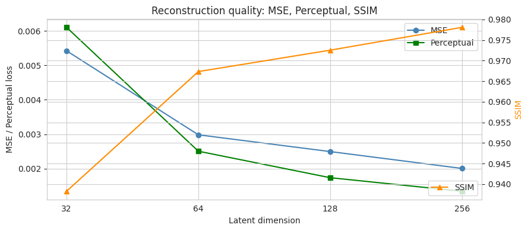

```python
# ---- Part 2.4: Perceptual loss ----
# Build a small CNN classifier using the Functional API so we can cleanly
# expose an intermediate feature layer for perceptual loss computation.

cls_inputs = keras.Input(shape=(28, 28, 1))
x = layers.Conv2D(32, 3, activation='relu', padding='same')(cls_inputs)
x = layers.MaxPool2D()(x)
feat = layers.Conv2D(64, 3, activation='relu', padding='same', name='feat')(x)
x = layers.MaxPool2D()(feat)
x = layers.Flatten()(x)
cls_outputs = layers.Dense(10)(x)

classifier = keras.Model(cls_inputs, cls_outputs, name='mnist_classifier')
classifier.compile(optimizer='adam',
                   loss=keras.losses.SparseCategoricalCrossentropy(from_logits=True),
                   metrics=['accuracy'])
classifier.fit(x_train_01, y_train_s, epochs=2, batch_size=128, verbose=0)
print("Classifier trained for feature extraction.")

# Build feature extractor from the 'feat' layer (Functional API exposes .input cleanly)
feat_model = keras.Model(classifier.input, classifier.get_layer('feat').output,
                         name='feature_extractor')
feat_model.trainable = False

def perceptual_loss(y_true, y_pred):
    f_true = feat_model(y_true, training=False)
    f_pred = feat_model(y_pred, training=False)
    return tf.reduce_mean(tf.square(f_true - f_pred))

# Compute perceptual loss for each AE
print("\nPerceptual loss across latent dimensions:")
print("="*55)
print(f"{'Latent dim':<12}{'MSE':<12}{'SSIM':<12}{'Perceptual':<12}")
print("="*55)
for ld in latent_dims:
    recon = autoencoders[ld].predict(x_test_01[:1000], verbose=0)
    pl = float(perceptual_loss(x_test_01[:1000], recon))
    results[ld]['perceptual'] = pl
    r = results[ld]
    print(f"{ld:<12}{r['mse']:<12.5f}{r['ssim']:<12.4f}{pl:<12.4f}")

# Plot all three metrics together
fig, ax1 = plt.subplots(figsize=(9, 4))
ax2 = ax1.twinx()
xs = [str(ld) for ld in latent_dims]
mses  = [results[ld]['mse']        for ld in latent_dims]
ssims = [results[ld]['ssim']       for ld in latent_dims]
pls   = [results[ld]['perceptual'] for ld in latent_dims]

ax1.plot(xs, mses, color='steelblue', marker='o', label='MSE')
ax1.plot(xs, pls,  color='green',     marker='s', label='Perceptual')
ax2.plot(xs, ssims, color='darkorange', marker='^', label='SSIM')
ax1.set_xlabel("Latent dimension")
ax1.set_ylabel("MSE / Perceptual loss")
ax2.set_ylabel("SSIM", color='darkorange')
ax1.legend(loc='upper right'); ax2.legend(loc='lower right')
plt.title("Reconstruction quality: MSE, Perceptual, SSIM")
plt.tight_layout(); plt.show()
```

### Part 2 Summary

The convolutional autoencoder outperforms the basic dense autoencoder because convolutional layers capture local stroke patterns more effectively. The latent-dimension sweep shows that **latent sizes of 64 to 128 provide the best balance**: lower values (32) lose detail, while higher values (256) yield only marginal improvement. SSIM increases and MSE decreases as the latent size grows, but with diminishing returns. The PCA projection of latent vectors shows that the autoencoder has learned to **cluster similar digits together without any label supervision**, demonstrating effective unsupervised representation learning.

### Part 3.1: Build VAE encoder, decoder, sampling layer and the VAE training class.

```python
# ---- Part 3.1: Variational Autoencoder ----
LATENT_DIM_VAE = 32

class Sampling(layers.Layer):
    """Reparameterisation trick: z = mu + sigma * eps"""
    def call(self, inputs):
        mu, logvar = inputs
        eps = tf.random.normal(shape=tf.shape(mu))
        return mu + tf.exp(0.5 * logvar) * eps

def build_vae_encoder(latent_dim=LATENT_DIM_VAE):
    inputs = keras.Input(shape=(28, 28, 1))
    x = layers.Conv2D(32, 3, strides=2, padding='same', activation='relu')(inputs)
    x = layers.Conv2D(64, 3, strides=2, padding='same', activation='relu')(x)
    x = layers.Flatten()(x)
    x = layers.Dense(128, activation='relu')(x)
    mu     = layers.Dense(latent_dim, name='mu')(x)
    logvar = layers.Dense(latent_dim, name='logvar')(x)
    z = Sampling()([mu, logvar])
    return keras.Model(inputs, [mu, logvar, z], name='vae_encoder')

def build_vae_decoder(latent_dim=LATENT_DIM_VAE):
    inputs = keras.Input(shape=(latent_dim,))
    x = layers.Dense(7*7*64, activation='relu')(inputs)
    x = layers.Reshape((7, 7, 64))(x)
    x = layers.Conv2DTranspose(64, 3, strides=2, padding='same', activation='relu')(x)
    x = layers.Conv2DTranspose(32, 3, strides=2, padding='same', activation='relu')(x)
    outputs = layers.Conv2D(1, 3, padding='same', activation='tanh')(x)
    return keras.Model(inputs, outputs, name='vae_decoder')

class VAE(keras.Model):
    def __init__(self, encoder, decoder, kl_weight=1.0, **kwargs):
        super().__init__(**kwargs)
        self.encoder = encoder
        self.decoder = decoder
        self.kl_weight = kl_weight
        self.total_loss_tracker = keras.metrics.Mean(name='total_loss')
        self.recon_loss_tracker = keras.metrics.Mean(name='recon_loss')
        self.kl_loss_tracker    = keras.metrics.Mean(name='kl_loss')

    @property
    def metrics(self):
        return [self.total_loss_tracker, self.recon_loss_tracker, self.kl_loss_tracker]

    def train_step(self, data):
        with tf.GradientTape() as tape:
            mu, logvar, z = self.encoder(data, training=True)
            recon = self.decoder(z, training=True)
            recon_loss = tf.reduce_mean(
                tf.reduce_sum(tf.square(data - recon), axis=[1, 2, 3])
            )
            kl_loss = tf.reduce_mean(
                -0.5 * tf.reduce_sum(1 + logvar - tf.square(mu) - tf.exp(logvar), axis=1)
            )
            total = recon_loss + self.kl_weight * kl_loss
        grads = tape.gradient(total, self.trainable_weights)
        self.optimizer.apply_gradients(zip(grads, self.trainable_weights))
        self.total_loss_tracker.update_state(total)
        self.recon_loss_tracker.update_state(recon_loss)
        self.kl_loss_tracker.update_state(kl_loss)
        return {m.name: m.result() for m in self.metrics}

vae_enc = build_vae_encoder()
vae_dec = build_vae_decoder()
vae = VAE(vae_enc, vae_dec, kl_weight=1.0)
vae.compile(optimizer=keras.optimizers.Adam(1e-3))

print("VAE Encoder summary:")
vae_enc.summary()
print("\nVAE Decoder summary:")
vae_dec.summary()
```

```
VAE Encoder summary:
```

```
Model: "vae_encoder"
```

```
┏━━━━━━━━━━━━━━━━━━━━━┳━━━━━━━━━━━━━━━━━━━┳━━━━━━━━━━━━┳━━━━━━━━━━━━━━━━━━━┓
┃ Layer (type)        ┃ Output Shape      ┃    Param # ┃ Connected to      ┃
┡━━━━━━━━━━━━━━━━━━━━━╇━━━━━━━━━━━━━━━━━━━╇━━━━━━━━━━━━╇━━━━━━━━━━━━━━━━━━━┩
│ input_layer_8       │ (None, 28, 28, 1) │          0 │ -                 │
│ (InputLayer)        │                   │            │                   │
├─────────────────────┼───────────────────┼────────────┼───────────────────┤
│ conv2d_14 (Conv2D)  │ (None, 14, 14,    │        320 │ input_layer_8[0]… │
│                     │ 32)               │            │                   │
├─────────────────────┼───────────────────┼────────────┼───────────────────┤
│ conv2d_15 (Conv2D)  │ (None, 7, 7, 64)  │     18,496 │ conv2d_14[0][0]   │
├─────────────────────┼───────────────────┼────────────┼───────────────────┤
│ flatten_7 (Flatten) │ (None, 3136)      │          0 │ conv2d_15[0][0]   │
├─────────────────────┼───────────────────┼────────────┼───────────────────┤
│ dense_11 (Dense)    │ (None, 128)       │    401,536 │ flatten_7[0][0]   │
├─────────────────────┼───────────────────┼────────────┼───────────────────┤
│ mu (Dense)          │ (None, 32)        │      4,128 │ dense_11[0][0]    │
├─────────────────────┼───────────────────┼────────────┼───────────────────┤
│ logvar (Dense)      │ (None, 32)        │      4,128 │ dense_11[0][0]    │
├─────────────────────┼───────────────────┼────────────┼───────────────────┤
│ sampling (Sampling) │ (None, 32)        │          0 │ mu[0][0],         │
│                     │                   │            │ logvar[0][0]      │
└─────────────────────┴───────────────────┴────────────┴───────────────────┘
```

```
 Total params: 428,608 (1.64 MB)
```

```
 Trainable params: 428,608 (1.64 MB)
```

```
 Non-trainable params: 0 (0.00 B)
```

```
VAE Decoder summary:
```

```
Model: "vae_decoder"
```

```
┏━━━━━━━━━━━━━━━━━━━━━━━━━━━━━━━━━┳━━━━━━━━━━━━━━━━━━━━━━━━┳━━━━━━━━━━━━━━━┓
┃ Layer (type)                    ┃ Output Shape           ┃       Param # ┃
┡━━━━━━━━━━━━━━━━━━━━━━━━━━━━━━━━━╇━━━━━━━━━━━━━━━━━━━━━━━━╇━━━━━━━━━━━━━━━┩
│ input_layer_9 (InputLayer)      │ (None, 32)             │             0 │
├─────────────────────────────────┼────────────────────────┼───────────────┤
│ dense_12 (Dense)                │ (None, 3136)           │       103,488 │
├─────────────────────────────────┼────────────────────────┼───────────────┤
│ reshape_5 (Reshape)             │ (None, 7, 7, 64)       │             0 │
├─────────────────────────────────┼────────────────────────┼───────────────┤
│ conv2d_transpose_8              │ (None, 14, 14, 64)     │        36,928 │
│ (Conv2DTranspose)               │                        │               │
├─────────────────────────────────┼────────────────────────┼───────────────┤
│ conv2d_transpose_9              │ (None, 28, 28, 32)     │        18,464 │
│ (Conv2DTranspose)               │                        │               │
├─────────────────────────────────┼────────────────────────┼───────────────┤
│ conv2d_16 (Conv2D)              │ (None, 28, 28, 1)      │           289 │
└─────────────────────────────────┴────────────────────────┴───────────────┘
```

```
 Total params: 159,169 (621.75 KB)
```

```
 Trainable params: 159,169 (621.75 KB)
```

```
 Non-trainable params: 0 (0.00 B)
```

### Part 3.2: Train the VAE, plot loss components, and generate new samples from the prior distribution.

```
422/422 ━━━━━━━━━━━━━━━━━━━━ 13s 15ms/step - kl_loss: 14.2048 - recon_loss: 164.4530 - total_loss: 178.6578
422/422 ━━━━━━━━━━━━━━━━━━━━ 2s 4ms/step - kl_loss: 25.0733 - recon_loss: 67.5874 - total_loss: 92.6608
422/422 ━━━━━━━━━━━━━━━━━━━━ 2s 4ms/step - kl_loss: 25.2686 - recon_loss: 52.4880 - total_loss: 77.7566
422/422 ━━━━━━━━━━━━━━━━━━━━ 2s 4ms/step - kl_loss: 25.2319 - recon_loss: 46.1020 - total_loss: 71.3340
422/422 ━━━━━━━━━━━━━━━━━━━━ 1s 3ms/step - kl_loss: 25.1943 - recon_loss: 42.6594 - total_loss: 67.8537
422/422 ━━━━━━━━━━━━━━━━━━━━ 2s 3ms/step - kl_loss: 25.2704 - recon_loss: 40.2476 - total_loss: 65.5180
422/422 ━━━━━━━━━━━━━━━━━━━━ 1s 3ms/step - kl_loss: 25.3300 - recon_loss: 38.8244 - total_loss: 64.1544
422/422 ━━━━━━━━━━━━━━━━━━━━ 1s 3ms/step - kl_loss: 25.4280 - recon_loss: 37.6135 - total_loss: 63.0415
422/422 ━━━━━━━━━━━━━━━━━━━━ 1s 3ms/step - kl_loss: 25.5388 - recon_loss: 36.7631 - total_loss: 62.3018
422/422 ━━━━━━━━━━━━━━━━━━━━ 1s 3ms/step - kl_loss: 25.6156 - recon_loss: 36.0249 - total_loss: 61.6405
422/422 ━━━━━━━━━━━━━━━━━━━━ 1s 3ms/step - kl_loss: 25.7068 - recon_loss: 35.3865 - total_loss: 61.0932
422/422 ━━━━━━━━━━━━━━━━━━━━ 2s 3ms/step - kl_loss: 25.7903 - recon_loss: 34.7464 - total_loss: 60.5367
422/422 ━━━━━━━━━━━━━━━━━━━━ 1s 3ms/step - kl_loss: 25.8691 - recon_loss: 34.2366 - total_loss: 60.1057
422/422 ━━━━━━━━━━━━━━━━━━━━ 2s 4ms/step - kl_loss: 25.9296 - recon_loss: 33.7785 - total_loss: 59.7081
422/422 ━━━━━━━━━━━━━━━━━━━━ 2s 4ms/step - kl_loss: 25.9955 - recon_loss: 33.3208 - total_loss: 59.3163
```

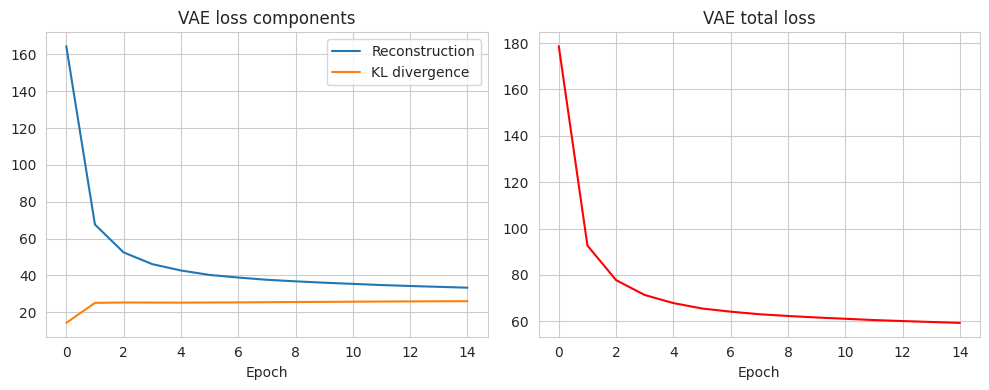

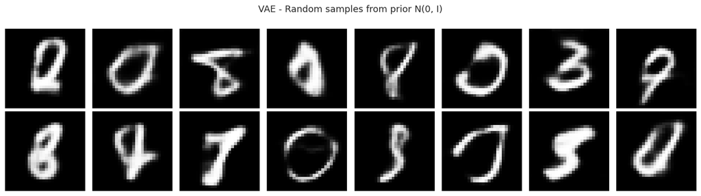

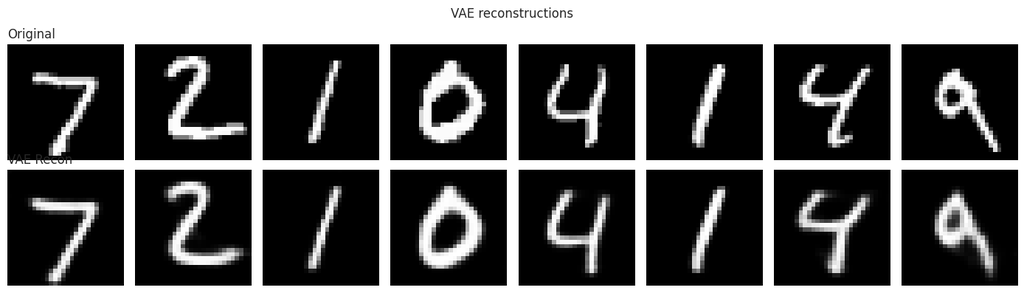

```python
# ---- Part 3.2: Train VAE and generate samples ----
vae_history = vae.fit(x_train_11, epochs=15, batch_size=128, verbose=1)

plt.figure(figsize=(10, 4))
plt.subplot(1, 2, 1)
plt.plot(vae_history.history['recon_loss'], label='Reconstruction')
plt.plot(vae_history.history['kl_loss'], label='KL divergence')
plt.title("VAE loss components"); plt.xlabel("Epoch"); plt.legend()

plt.subplot(1, 2, 2)
plt.plot(vae_history.history['total_loss'], color='red')
plt.title("VAE total loss"); plt.xlabel("Epoch")
plt.tight_layout(); plt.show()

n_new = 16
z_random = tf.random.normal(shape=(n_new, LATENT_DIM_VAE))
generated = vae_dec(z_random).numpy()
generated = (generated + 1) / 2

fig, axes = plt.subplots(2, 8, figsize=(14, 4))
for i, ax in enumerate(axes.flatten()):
    ax.imshow(generated[i].squeeze(), cmap='gray'); ax.axis('off')
plt.suptitle("VAE - Random samples from prior N(0, I)", fontsize=13)
plt.tight_layout(); plt.show()

test_input_11 = x_test_11[:8]
mu_t, logvar_t, z_t = vae_enc(test_input_11)
recon_t = vae_dec(z_t).numpy()

fig, axes = plt.subplots(2, 8, figsize=(14, 4))
for i in range(8):
    axes[0, i].imshow(((test_input_11[i]+1)/2).squeeze(), cmap='gray'); axes[0, i].axis('off')
    axes[1, i].imshow(((recon_t[i]+1)/2).squeeze(), cmap='gray');       axes[1, i].axis('off')
axes[0, 0].set_title("Original", loc='left')
axes[1, 0].set_title("VAE Recon", loc='left')
plt.suptitle("VAE reconstructions"); plt.tight_layout(); plt.show()
```

### Part 3.3: Perform latent-space interpolation between two digits, traverse individual latent dimensions, and compare AE vs VAE latent geometry.

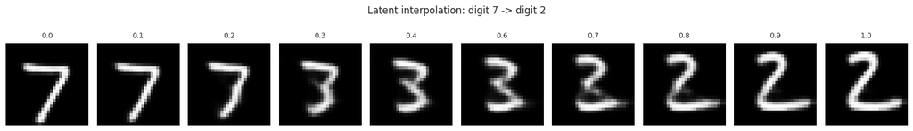

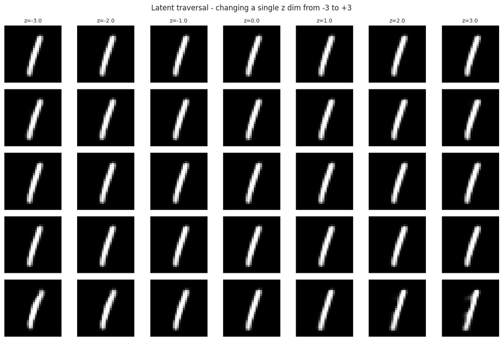

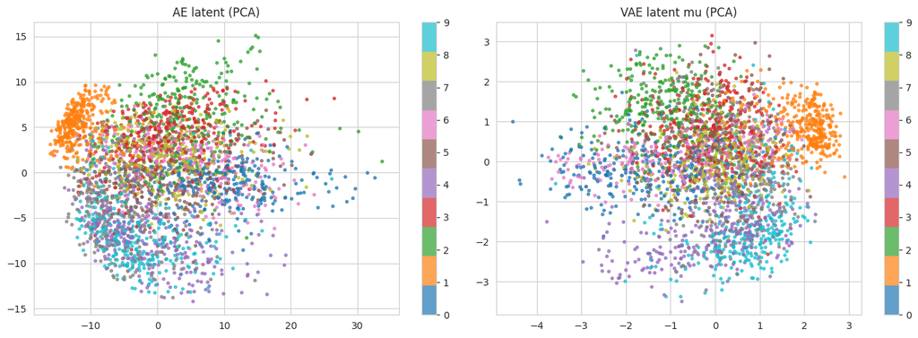

```python
# ---- Part 3.3: Latent interpolation, traversal, AE vs VAE comparison ----
idx_a, idx_b = 0, 1
img_a = x_test_11[idx_a:idx_a+1]
img_b = x_test_11[idx_b:idx_b+1]

mu_a, _, _ = vae_enc(img_a)
mu_b, _, _ = vae_enc(img_b)

n_steps = 10
alphas = np.linspace(0, 1, n_steps)
interp_imgs = []
for a in alphas:
    z = (1 - a) * mu_a + a * mu_b
    interp_imgs.append(vae_dec(z).numpy()[0])

fig, axes = plt.subplots(1, n_steps, figsize=(16, 2.5))
for i, img in enumerate(interp_imgs):
    axes[i].imshow(((img+1)/2).squeeze(), cmap='gray'); axes[i].axis('off')
    axes[i].set_title(f"{alphas[i]:.1f}", fontsize=9)
plt.suptitle(f"Latent interpolation: digit {y_test[idx_a]} -> digit {y_test[idx_b]}")
plt.tight_layout(); plt.show()

base_mu, _, _ = vae_enc(x_test_11[5:6])
base_z = base_mu.numpy()[0]

dims_to_traverse = [0, 1, 2, 3, 4]
values = np.linspace(-3, 3, 7)

fig, axes = plt.subplots(len(dims_to_traverse), len(values), figsize=(12, 8))
for r, d in enumerate(dims_to_traverse):
    for c, v in enumerate(values):
        z = base_z.copy()
        z[d] = v
        img = vae_dec(z[np.newaxis, :]).numpy()[0]
        axes[r, c].imshow(((img+1)/2).squeeze(), cmap='gray'); axes[r, c].axis('off')
        if r == 0: axes[r, c].set_title(f"z={v:.1f}", fontsize=9)
    axes[r, 0].set_ylabel(f"dim {d}", rotation=0, labelpad=25)
plt.suptitle("Latent traversal - changing a single z dim from -3 to +3")
plt.tight_layout(); plt.show()

mu_all, _, _ = vae_enc.predict(x_test_11[:3000], verbose=0)
pca_vae = PCA(n_components=2).fit_transform(mu_all)

fig, axes = plt.subplots(1, 2, figsize=(14, 5))
sc1 = axes[0].scatter(pca[:, 0], pca[:, 1], c=y_test[:3000], cmap='tab10', s=8, alpha=0.7)
axes[0].set_title("AE latent (PCA)"); plt.colorbar(sc1, ax=axes[0])

sc2 = axes[1].scatter(pca_vae[:, 0], pca_vae[:, 1], c=y_test[:3000], cmap='tab10', s=8, alpha=0.7)
axes[1].set_title("VAE latent mu (PCA)"); plt.colorbar(sc2, ax=axes[1])
plt.tight_layout(); plt.show()
```

### Part 3.4: Compare different priors using Beta-VAE — train with three KL weights and analyse the reconstruction-versus-disentanglement trade-off.

```
=== Training Beta-VAE with beta = 0.5 ===
  Final recon loss: 28.72 | Final KL loss: 37.10

=== Training Beta-VAE with beta = 1.0 ===
  Final recon loss: 36.13 | Final KL loss: 26.45

=== Training Beta-VAE with beta = 4.0 ===
  Final recon loss: 70.80 | Final KL loss: 11.58
```

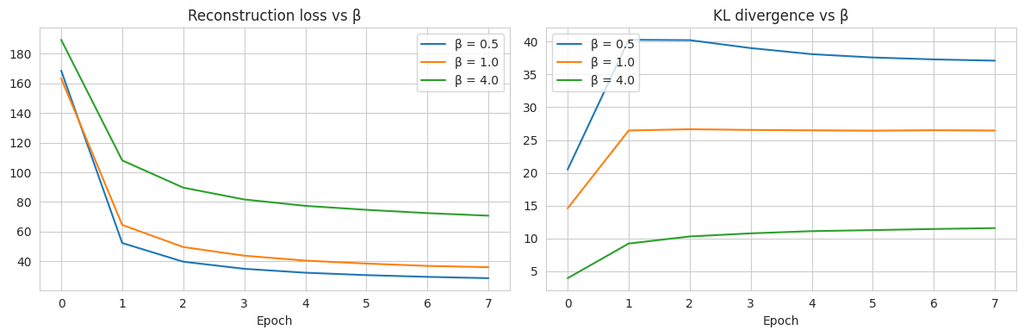

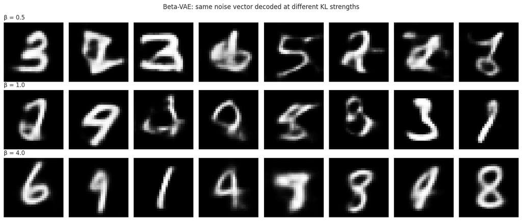

[output not shown]

```python
# ---- Part 3.4: Beta-VAE comparison (different posterior strength) ----
# Beta < 1 weakens the prior (closer to a plain AE)
# Beta = 1 is the standard VAE
# Beta > 1 enforces a stronger prior, encouraging disentanglement at the cost of reconstruction

beta_values = [0.5, 1.0, 4.0]
beta_models = {}
beta_histories = {}

for beta in beta_values:
    print(f"\n=== Training Beta-VAE with beta = {beta} ===")
    enc_b = build_vae_encoder()
    dec_b = build_vae_decoder()
    m = VAE(enc_b, dec_b, kl_weight=beta)
    m.compile(optimizer=keras.optimizers.Adam(1e-3))
    h = m.fit(x_train_11, epochs=8, batch_size=128, verbose=0)
    beta_models[beta] = (enc_b, dec_b)
    beta_histories[beta] = h.history
    print(f"  Final recon loss: {h.history['recon_loss'][-1]:.2f} | "
          f"Final KL loss: {h.history['kl_loss'][-1]:.2f}")

# Plot loss curves side by side
fig, axes = plt.subplots(1, 2, figsize=(12, 4))
for beta in beta_values:
    axes[0].plot(beta_histories[beta]['recon_loss'], label=f"β = {beta}")
    axes[1].plot(beta_histories[beta]['kl_loss'],    label=f"β = {beta}")
axes[0].set_title("Reconstruction loss vs β"); axes[0].set_xlabel("Epoch"); axes[0].legend()
axes[1].set_title("KL divergence vs β");      axes[1].set_xlabel("Epoch"); axes[1].legend()
plt.tight_layout(); plt.show()

# Compare generated samples across beta values
fig, axes = plt.subplots(len(beta_values), 8, figsize=(14, 6))
fixed_z = tf.random.normal([8, LATENT_DIM_VAE])  # same z for fair comparison
for r, beta in enumerate(beta_values):
    _, dec_b = beta_models[beta]
    samples = ((dec_b(fixed_z).numpy() + 1) / 2).squeeze()
    for c in range(8):
        axes[r, c].imshow(samples[c], cmap='gray'); axes[r, c].axis('off')
    axes[r, 0].set_title(f"β = {beta}", loc='left', fontsize=11)
plt.suptitle("Beta-VAE: same noise vector decoded at different KL strengths")
plt.tight_layout(); plt.show()

print("\nObservation:")
print("- β = 0.5 -> sharper but less regular latent space (closer to plain AE)")
print("- β = 1.0 -> standard VAE, balanced reconstruction and prior matching")
print("- β = 4.0 -> stronger disentanglement, blurrier samples, more uniform latent")
```

### Part 3.5: Compare a stronger posterior approximation by varying the latent dimension, and contrast Gaussian versus Laplacian prior assumptions.

```
=== VAE with latent dim = 16 (posterior expressiveness) ===
  recon: 38.03 | kl: 26.19

=== VAE with latent dim = 32 (posterior expressiveness) ===
  recon: 41.32 | kl: 25.00

=== VAE with latent dim = 64 (posterior expressiveness) ===
  recon: 37.79 | kl: 28.05
```

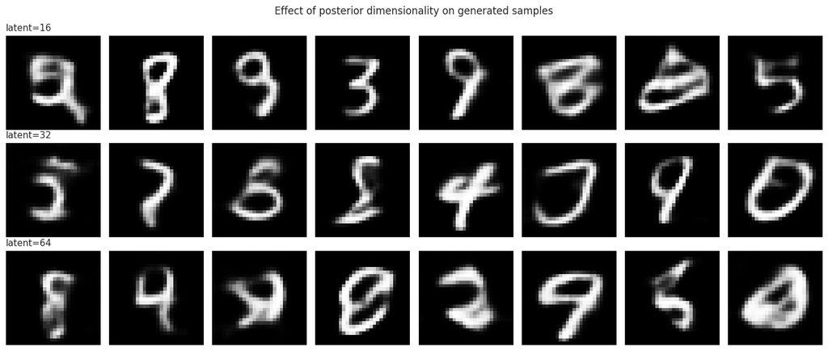

```
=== Prior comparison on the standard VAE decoder ===
```

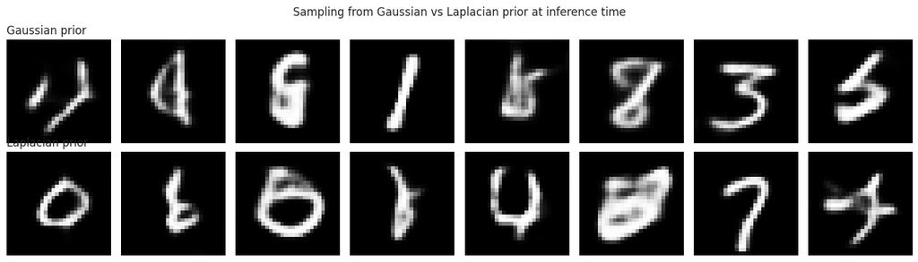

```
Observation: the VAE was trained with a Gaussian prior, so Gaussian samples
decode cleanly. Laplacian samples have heavier tails and produce more out-of-
distribution outputs, illustrating that the choice of prior must match the
training-time KL term to obtain coherent generations.
```

```python
# ---- Part 3.5: Different posterior approximations and prior comparison ----
# (a) Posterior expressiveness via latent dimension
# (b) Prior comparison: standard Gaussian N(0, I) vs Laplacian L(0, 1)

# (a) Vary latent dim — controls how expressive the posterior is
posterior_dims = [16, 32, 64]
posterior_results = {}
for d in posterior_dims:
    print(f"\n=== VAE with latent dim = {d} (posterior expressiveness) ===")
    enc_p = build_vae_encoder(latent_dim=d)
    dec_p = build_vae_decoder(latent_dim=d)
    m = VAE(enc_p, dec_p, kl_weight=1.0)
    m.compile(optimizer=keras.optimizers.Adam(1e-3))
    h = m.fit(x_train_11, epochs=6, batch_size=128, verbose=0)
    posterior_results[d] = (enc_p, dec_p, h.history)
    print(f"  recon: {h.history['recon_loss'][-1]:.2f} | "
          f"kl: {h.history['kl_loss'][-1]:.2f}")

# Visualise samples at each dim (sample fresh z from prior)
fig, axes = plt.subplots(len(posterior_dims), 8, figsize=(14, 6))
for r, d in enumerate(posterior_dims):
    _, dec_p, _ = posterior_results[d]
    z = tf.random.normal([8, d])
    samples = ((dec_p(z).numpy() + 1) / 2).squeeze()
    for c in range(8):
        axes[r, c].imshow(samples[c], cmap='gray'); axes[r, c].axis('off')
    axes[r, 0].set_title(f"latent={d}", loc='left', fontsize=11)
plt.suptitle("Effect of posterior dimensionality on generated samples")
plt.tight_layout(); plt.show()

# (b) Prior comparison: sample from Gaussian vs Laplacian using the standard VAE
print("\n=== Prior comparison on the standard VAE decoder ===")
fig, axes = plt.subplots(2, 8, figsize=(14, 4))

z_gauss = tf.random.normal([8, LATENT_DIM_VAE])              # N(0, I)
z_lap   = tf.cast(np.random.laplace(0.0, 1.0,
                  size=(8, LATENT_DIM_VAE)), tf.float32)      # Laplace(0, 1)

samp_gauss = ((vae_dec(z_gauss).numpy() + 1) / 2).squeeze()
samp_lap   = ((vae_dec(z_lap).numpy()   + 1) / 2).squeeze()

for c in range(8):
    axes[0, c].imshow(samp_gauss[c], cmap='gray'); axes[0, c].axis('off')
    axes[1, c].imshow(samp_lap[c],   cmap='gray'); axes[1, c].axis('off')
axes[0, 0].set_title("Gaussian prior", loc='left')
axes[1, 0].set_title("Laplacian prior", loc='left')
plt.suptitle("Sampling from Gaussian vs Laplacian prior at inference time")
plt.tight_layout(); plt.show()

print("\nObservation: the VAE was trained with a Gaussian prior, so Gaussian samples")
print("decode cleanly. Laplacian samples have heavier tails and produce more out-of-")
print("distribution outputs, illustrating that the choice of prior must match the")
print("training-time KL term to obtain coherent generations.")
```